# McKinsey Hackathon - Prediction of Probability of Stroke for Each Patient

Midhun Thaduru

14 April 2018

# Introduction

[McKinsey Hiring Hackathon in Healthcare Analytics](https://datahack.analyticsvidhya.com/contest/mckinsey-analytics-online-hackathon/) is a prediction of probability problem for stroke happening to the patients. The prediction of stroke will help the doctors to take proactive health measures for these patients.

```r
# Loading the training set
dtTrain <- fread(
  paste0(
    Sys.getenv("MyGitRepo"),
    "/McKinsey/Datasets/train_ajEneEa.csv"
  )
)

# Grouping Ages
dtTrain[, AgeBin := cut(age,
                        breaks = seq(0, 90, 10),
                        include.lowest = T)]

# Creating Bins and categorise missing values as Unknown
dtTrain[, BMIBin := cut(bmi,
                        breaks = c(0, 15, 16, 18.5, 25, 30, 35, 40, 100),
                        labels = c("Very severely underweight",
                                   "Severely underweight",
                                   "Underweight",
                                   "Normal",
                                   "Overweight",
                                   "Moderately obese",
                                   "Severely obese",
                                   "Very severely obese"),
                        include.lowest = T)]

dtTrain[is.na(BMIBin), BMIBin := "Unknown"]

dtTrain[, BMIBin := factor(BMIBin,
                           levels = c("Very severely underweight",
                                      "Severely underweight",
                                      "Underweight",
                                      "Normal",
                                      "Overweight",
                                      "Moderately obese",
                                      "Severely obese",
                                      "Very severely obese",
                                      "Unknown"))]

# Empty string in smoking_status are coverted as unknown
dtTrain[, smoking_status := ifelse(smoking_status == "",
                                   "Unknown", smoking_status)]

# Grouping Glucose levels as bins
dtTrain[, GlucoseLevelBins := cut(avg_glucose_level,
                                  breaks = seq(50, 300, 50),
                                  include.lowest = T)]
```

The client has collected several health, demographic and lifestyle details of patients such as gender, age, hypertension, heart_disease, ever_married, work_type, Residence_type, avg_glucose_level, bmi, smoking_status, stroke, AgeBin, BMIBin, GlucoseLevelBins.

# Exploratory Data Analysis

Single variable analysis will help understand the importance each variable

## Age Group

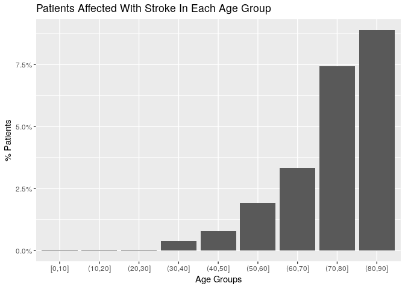

```r
AgeSampleGroup <- dtTrain[, .(Sample_N = .N),
                        by = "AgeBin"][, Sample_pct := Sample_N/sum(Sample_N)]

AgeStrokeGroup <- dtTrain[stroke == T,
                          .(Stroke_N = .N),
                          by = c("AgeBin")][, Stroke_pct := Stroke_N/sum(Stroke_N)]

AgeGroup <- merge(AgeSampleGroup,
                  AgeStrokeGroup,
                  by = "AgeBin",
                  all = T)

AgeGroup[, N_pct := Stroke_N/Sample_N]

ggplot(AgeGroup) +
  geom_bar(aes(x = AgeBin, y = N_pct), stat = "identity") +
  scale_y_continuous(labels = scales::percent) +
  xlab("Age Groups") +
  ylab("% Patients") +
  ggtitle("Patients Affected With Stroke In Each Age Group")
```

Number of people affected with stroke increased with Age Group.

## BMI Group

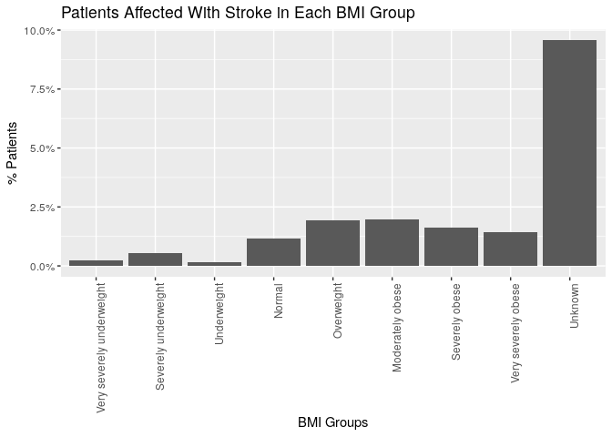

```r
BMISampleGroup <- dtTrain[, .(Sample_N = .N),
                          by = BMIBin][,
                    Sample_pct := Sample_N/sum(Sample_N)]


BMIStrokeGroup <- dtTrain[stroke == T, .(Stroke_N = .N),
                          by = BMIBin][, Stroke_pct := Stroke_N/sum(Stroke_N)]


BMIGroup <- merge(BMISampleGroup,
                  BMIStrokeGroup,
                  by = "BMIBin",
                  all = T)

BMIGroup[, N_pct := Stroke_N/Sample_N]

ggplot(BMIGroup) +
  geom_bar(aes(x = BMIBin, y = N_pct), stat = "identity") +
  scale_y_continuous(labels = scales::percent) +
  xlab("BMI Groups") +
  ylab("% Patients") +
  ggtitle("Patients Affected With Stroke in Each BMI Group") +
  theme(axis.text.x = element_text(angle = 90, hjust = 1))
```

Note: BMI index is grouped based on [WHO Statistical categories](https://en.wikipedia.org/wiki/Body_mass_index#Categories) to understand the pattern of BMI in the patients who were affected by stroke. All the *NAs* are grouped as **Unknown**.

## Work Type

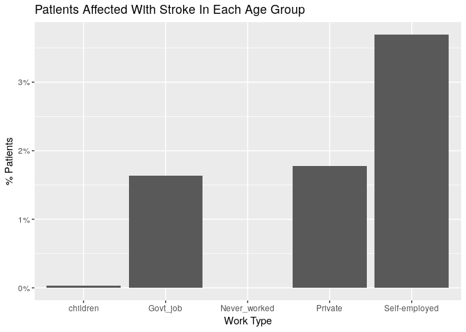

```r
# How does work type affect the stroke
WorkTypeSampleGroups <- dtTrain[, .(Samaple_N = .N),
                                by = "work_type"][,
                          Sample_pct := Samaple_N/sum(Samaple_N)]

WorkTypeStrokeGroups <- dtTrain[stroke == T, .(Stroke_N = .N),
                            by = "work_type"][,
                          Stroke_pct := Stroke_N/sum(Stroke_N)]

WorkType <- merge(WorkTypeSampleGroups,
                  WorkTypeStrokeGroups,
                  by = "work_type",
                  all = T)

WorkType[, c("Stroke_N",
             "Stroke_pct") := lapply(.SD,
                                     function(x){
                                       x = ifelse(is.na(x), 0, x)
                                     }),
         .SDcols = c("Stroke_N",
                     "Stroke_pct")]

WorkType[, N_pct := Stroke_N/Samaple_N]

ggplot(WorkType) +
  geom_bar(aes(x = work_type, y = N_pct), stat = "identity") +
  scale_y_continuous(labels = scales::percent) +
  xlab("Work Type") +
  ylab("% Patients") +
  ggtitle("Patients Affected With Stroke In Each Age Group")
```

People who are self-employed are more prone to stroke.

## Hypertension

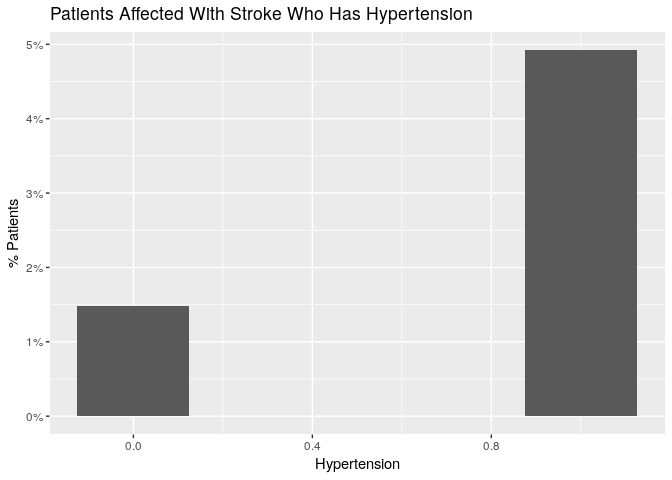

```r
HypertensionSampleGroup <- dtTrain[, .(Sample_N = .N),
                                   by = hypertension][,
                            Sample_pct := Sample_N/sum(Sample_N)]

HypertensionStrokeGroup <- dtTrain[stroke == T, .(Stroke_N = .N),
                                   by = hypertension][,
                          Stroke_pct := Stroke_N/sum(Stroke_N)]

Hypertension <- merge(HypertensionSampleGroup,
                      HypertensionStrokeGroup,
                      by = "hypertension",
                      all = T)

Hypertension[, N_pct := Stroke_N/Sample_N]

ggplot(Hypertension) +
  geom_bar(aes(x = hypertension, y = N_pct),
           stat = "identity", width = 0.25) +
  scale_y_continuous(labels = scales::percent) +
  xlab("Hypertension") +
  ylab("% Patients") +
  ggtitle("Patients Affected With Stroke Who Has Hypertension")
```

Patients with hypertension has high risk of stroke.

## Heart Diseases

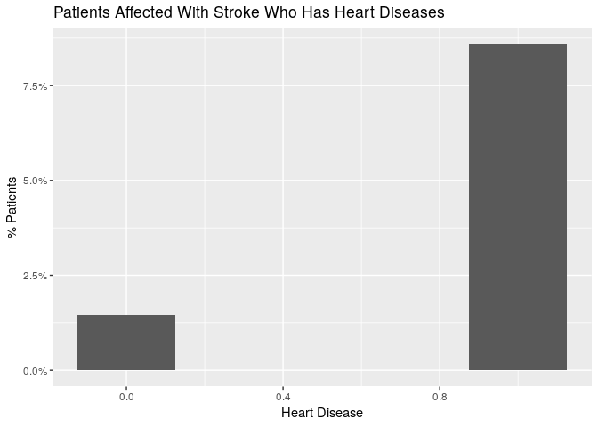

```r
HeartDiseaseSampleGroup <- dtTrain[, .(Sample_N = .N),
                                   by = heart_disease][,
                          Sample_pct := Sample_N/sum(Sample_N)]

HeartDiseaseStrokeGroup <- dtTrain[stroke == TRUE, .(Stroke_N = .N),
                                   by = heart_disease][,
                              Stroke_pct := Stroke_N/sum(Stroke_N)]

HeartDisease <- merge(HeartDiseaseSampleGroup,
                      HeartDiseaseStrokeGroup,
                      by = "heart_disease",
                      all = T)

HeartDisease[, N_pct := Stroke_N/Sample_N]

ggplot(HeartDisease) +
  geom_bar(aes(x = heart_disease, y = N_pct),
           stat = "identity", width = 0.25) +
  scale_y_continuous(labels = scales::percent) +
  xlab("Heart Disease") +
  ylab("% Patients") +
  ggtitle("Patients Affected With Stroke Who Has Heart Diseases")
```

Patients with heart disease high chance of stroke.

## Smoking Status

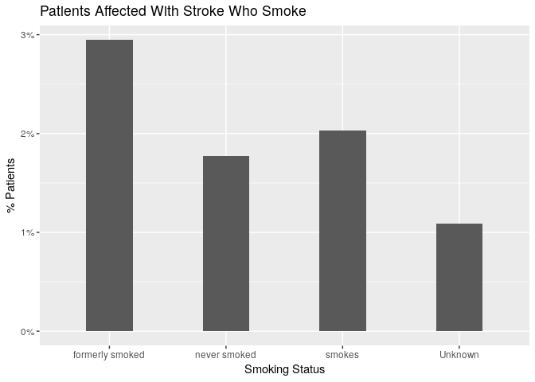

```r
SmokingSampleGroup <- dtTrain[, .(Sample_N = .N),
                              by = smoking_status][,
                          Sample_pct := Sample_N/sum(Sample_N)]


SmokingStrokeGroup <- dtTrain[stroke == TRUE, .(Stroke_N = .N),
                              by = smoking_status][,
                       Stroke_pct := Stroke_N/sum(Stroke_N)]

Smoking <- merge(SmokingSampleGroup,
                 SmokingStrokeGroup,
                 by = "smoking_status",
                 all = T)

Smoking[, N_pct := Stroke_N/Sample_N]

ggplot(Smoking) +
  geom_bar(aes(x = smoking_status, y = N_pct),
           stat = "identity", width = 0.4) +
  scale_y_continuous(labels = scales::percent) +
  xlab("Smoking Status") +
  ylab("% Patients") +
  ggtitle("Patients Affected With Stroke Who Smoke")
```

Hypothesis is patients who formerly smoked or smokes has higher chance of stroke but there data does not show significant difference with the patients who never smoked.

## Healthy Patients

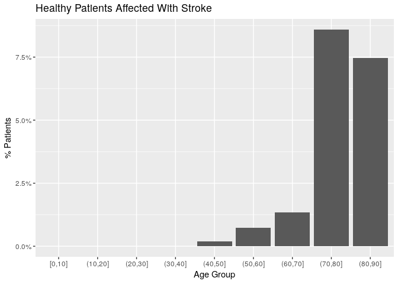

```r
HealthySampleGroup <- dtTrain[hypertension == F &
                               heart_disease == F &
                               smoking_status == "never smoked" &
                               BMIBin == "Normal",
                             .(Sample_N = .N),
                             by = AgeBin][, Sample_pct := Sample_N/sum(Sample_N)]

HealthyStrokeGroup <- dtTrain[hypertension == F &
                               heart_disease == F &
                               smoking_status == "never smoked" &
                               BMIBin == "Normal" &
                               stroke == T,
                             .(Stroke_N = .N),
                             by = AgeBin][, Stroke_pct := Stroke_N/sum(Stroke_N)]

HealthyGroup <- merge(HealthySampleGroup,
                      HealthyStrokeGroup,
                      by = "AgeBin",
                      all = T)

HealthyGroup[, c("Stroke_N",
                 "Stroke_pct") := lapply(.SD,
                                         function(x){
                                           x = ifelse(is.na(x), 0, x)
                                         }),
             .SDcols = c("Stroke_N",
                         "Stroke_pct")]

HealthyGroup[, N_pct := Stroke_N/Sample_N]

ggplot(HealthyGroup) +
  geom_bar(aes(x = AgeBin, y = N_pct), stat = "identity") +
  scale_y_continuous(labels = scales::percent) +
  xlab("Age Group") +
  ylab("% Patients") +
  ggtitle("Healthy Patients Affected With Stroke")
```

Patients who were healthy and affected by stroke belong to the higher age group.

## Gender

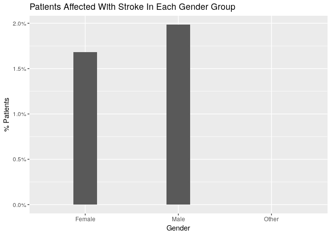

```r
GenderSampleGroups <- dtTrain[, .(Sample_N = .N),
                                     by = "gender"][,
                                  Sample_pct := Sample_N/sum(Sample_N)]

GenderStrokeGroups <- dtTrain[stroke == T, .(Stroke_N = .N),
                                     by = "gender"][,
                                  Stroke_pct := Stroke_N/sum(Stroke_N)]

Gender <- merge(GenderSampleGroups,
                GenderStrokeGroups,
                by = "gender",
                all = T)

Gender[, N_pct := Stroke_N/Sample_N]

ggplot(Gender) +
  geom_bar(aes(x = gender, y = N_pct),
           stat = "identity", width = 0.25) +
  scale_y_continuous(labels = scales::percent) +
  xlab("Gender") +
  ylab("% Patients") +
  ggtitle("Patients Affected With Stroke In Each Gender Group")
```

Gender doesn’t show significant difference in stroke.

## Residence Type

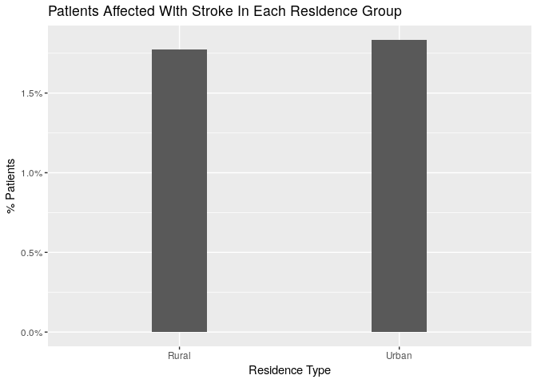

```r
# How does Residence_type affect the stroke
ResidenceTypeSampleGroups <- dtTrain[, .(Sample_N = .N),
                                     by = "Residence_type"][,
                                  Sample_pct := Sample_N/sum(Sample_N)]

ResidenceTypeStrokeGroups <- dtTrain[stroke == TRUE, .(Stroke_N = .N),
                                     by = "Residence_type"][,
                                    Stroke_pct := Stroke_N/sum(Stroke_N)]

ResidenceType <- merge(ResidenceTypeSampleGroups,
                       ResidenceTypeStrokeGroups,
                       by = "Residence_type")

ResidenceType[, N_pct := Stroke_N/Sample_N]

ggplot(ResidenceType) +
  geom_bar(aes(x = Residence_type, y = N_pct),
           stat = "identity", width = 0.25) +
  scale_y_continuous(labels = scales::percent) +
  xlab("Residence Type") +
  ylab("% Patients") +
  ggtitle("Patients Affected With Stroke In Each Residence Group")
```

Patients who live in rural or urban does not significant difference in stroke.

## Marital Status

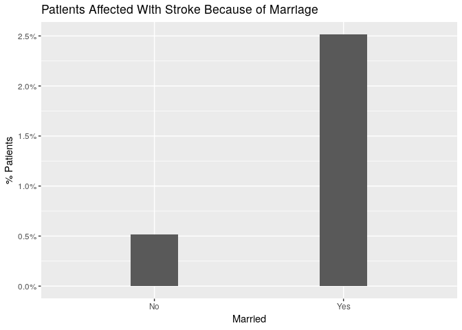

```r
EverMarriedSampleGroup <- dtTrain[, .(Sample_N = .N),
                       by = ever_married][,
                    Sample_pct := Sample_N/sum(Sample_N)]


EverMarriedStrokeGroup <- dtTrain[stroke == T, .(Stroke_N = .N),
                                  by = ever_married][,
                              Stroke_pct := Stroke_N/sum(Stroke_N)]

EverMarried <- merge(EverMarriedSampleGroup,
                     EverMarriedStrokeGroup,
                     by = "ever_married",
                     all = T)

EverMarried[, N_pct := Stroke_N/Sample_N]

ggplot(EverMarried) +
  geom_bar(aes(x = ever_married, y = N_pct),
           stat = "identity", width = 0.25) +
  scale_y_continuous(labels = scales::percent) +
  xlab("Married") +
  ylab("% Patients") +
  ggtitle("Patients Affected With Stroke Because of Marriage")
```

Patients who are married has higher stroke % compared to single but correlation does not mean causation.

```r
# Wrangling Testing Dataset
dtTest <- fread(
  paste0(
    Sys.getenv("MyGitRepo"),
    "/McKinsey/Datasets/test_v2akXPA.csv"
  )
)

dtTest[, AgeBin := cut(age,
                       breaks = seq(0, 90, 10),
                       include.lowest = T)]

dtTest[, BMIBin := cut(bmi,
                        breaks = c(0, 15, 16, 18.5, 25, 30, 35, 40, 100),
                        labels = c("Very severely underweight",
                                   "Severely underweight",
                                   "Underweight",
                                   "Normal",
                                   "Overweight",
                                   "Moderately obese",
                                   "Severely obese",
                                   "Very severely obese"),
                        include.lowest = T)]

dtTest[is.na(BMIBin), BMIBin := "Unknown"]

dtTest[, BMIBin := factor(BMIBin,
                           levels = c("Very severely underweight",
                                      "Severely underweight",
                                      "Underweight",
                                      "Normal",
                                      "Overweight",
                                      "Moderately obese",
                                      "Severely obese",
                                      "Very severely obese",
                                      "Unknown"))]

dtTest[, smoking_status := ifelse(smoking_status == "",
                                   "Unknown", smoking_status)]

dtTest[, GlucoseLevelBins := cut(avg_glucose_level,
                                  breaks = seq(50, 300, 50),
                                  include.lowest = T)]
```

```r
# Submission file
dtSubmission <- fread(
  paste0(
    Sys.getenv("MyGitRepo"),
    "/McKinsey/Datasets/sample_submission_1.csv"
  )
)
```

# Modelling

## Logistic Regression

```r
model1 <- glm(stroke ~ age + gender + hypertension + heart_disease +
                smoking_status + avg_glucose_level + BMIBin + work_type +
                ever_married + Residence_type,
    data = dtTrain, family = binomial(link = "logit"))

varImp(model1)
```

```
##                                Overall
## age                        22.32469475
## genderMale                  0.64722291
## genderOther                 0.01766679
## hypertension                2.42163222
## heart_disease               5.42872272
## smoking_statusnever smoked  0.02089828
## smoking_statussmokes        1.26969076
## smoking_statusUnknown       0.80162350
## avg_glucose_level           4.53799733
## BMIBinSeverely underweight  0.76573227
## BMIBinUnderweight           0.74217389
## BMIBinNormal                0.33680522
## BMIBinOverweight            0.26197172
## BMIBinModerately obese      0.26966927
## BMIBinSeverely obese        0.36236570
## BMIBinVery severely obese   0.30199961
## BMIBinUnknown               0.97566569
## work_typeGovt_job           0.30294291
## work_typeNever_worked       0.05495870
## work_typePrivate            0.45404602
## work_typeSelf-employed      0.40843644
## ever_marriedYes             0.87557247
## Residence_typeUrban         0.23215722
```

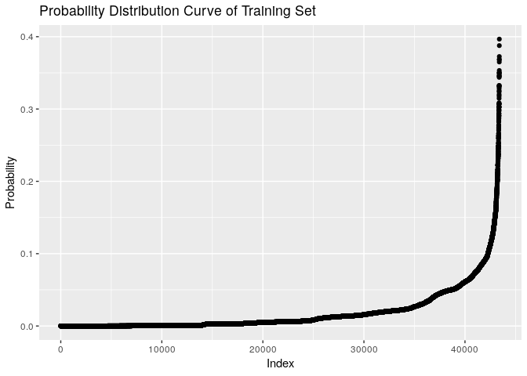

```r
# BMI values have been missing
# BMI Index has been grouped based on WHO Statistical categories
# Missing BMI values are grouped as Unknown
model2 <- glm(stroke ~ AgeBin + hypertension + heart_disease +
                smoking_status + GlucoseLevelBins + BMIBin + work_type,
    data = dtTrain, family = binomial(link = "probit"))

dtTrain[, predictedProbabilites := predict(model2, type = "response")]

dtProbCurve <- as.data.table(dtTrain[, predictedProbabilites])

setnames(dtProbCurve, "predictedProbabilites")

setorder(dtProbCurve, "predictedProbabilites")

ggplot(dtProbCurve) +
     geom_point(aes(x = as.numeric(row.names(dtProbCurve)),
                y = predictedProbabilites)) +
  xlab("Index") +
  ylab("Probability") +
  ggtitle("Probability Distribution Curve of Training Set")
```

```r
dtTrain[, predictedStroke := ifelse(predictedProbabilites > 0.030,
                                    TRUE, FALSE)]

# # Confusion Matrix
# confusionMatrix(dtTrain$stroke, dtTrain$predictedStroke)

dtSubmission[, stroke := predict(model2, dtTest, type = "response")]
```

```r
write.csv(
  dtSubmission,
  paste0(
    Sys.getenv("MyGitRepo"),
    "/McKinsey/Datasets/sample_submission_1.csv"
  ),
  row.names = F
)
```